# Multiple instance based deep classification for mass spectrometry imaging

Dan Guo

5/26/2022

# Introduction

*CardinalNN* is a side package of *Cardinal*. It provides both semi-supervised and fully-supervised deep learning methods for tissue classification using Mass Spectrometry Imaging (MSI) data. The neural network used as classifier is convolutional neural network (CNN).

- *fully supervised*. It is the same as standard supervised classification and it is used when the ground-truth labels of pixels are known.
- *Multiple instance*. It is semi-supervised classification and it is used when only the ground-truth labels of tissues are known while no labels for pixels. The assumption is that positive tissues can contain both positive and negative pixels, while negative tissues can only contain negative pixels.

# Installation

*CardinalNN* development version can be installed via the *BiocManager* package.

```r
install.packages("BiocManager")
BiocManager::install(version='devel')
BiocManager::install("CardinalNN")
```

The same function can be used to update *CardinalNN* and other Bioconductor packages.

Once installed, *CardinalNN* can be loaded with `library()`:

```r
library(CardinalNN)
```

*CardinalNN* an R package but it relies on Python. Therefore it requires both R and Python to be installed. However, the Python codes are excuted backend and the usage of this package does not require writing any Python codes. Download python 3 from https://www.python.org/downloads/ and install. After installing python, install python package `DeepMSI`:

```r
git clone https://github.com/DanGuo1223/DeepMSI.git
sudo python3 setup.py install
```

# Load the training and testing datasets

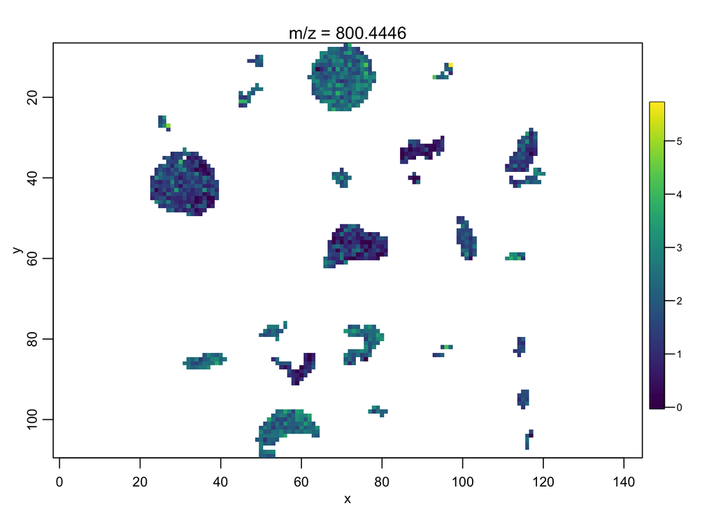

```r
load('mse_train.rdata')
mse <- mse_train
load('mse_test.rdata')
mse_train <- mse_test
mse_test <- mse_train
image(mse,feature=1)
```

# Fully supervised training

Use `multipleInstanceCNN()` and specify the parameter `method` as ‘fully_supervised’ to perform standard supervised training on CNN. `num_epochs` is the iteration number of complete data passes. Other parameters such as `batch_size`, `lr`, and `optim`, please use `help('multipleInstanceCNN')`. The network structure and training processes will be printed out in R console.

```r
micnn_supervised <- multipleInstanceCNN(mse_train, mse_train$plabel, model_name = 'bladder_classifier1', method = 'fully_supervised', num_epochs = 1)
```

[figure not shown]

We can use `summary()` to summarize the trained model.

```r
summary(micnn_supervised)
```

```
## DNN classification:
##
##  Classification on 2 classes: 0 1
##  training = fully_supervised
##  epochs = 1
##
##       classifier_name         training  Accuracy Sensitivity Specificity
## 1 bladder_classifier1 fully_supervised 0.7412713   0.5398551   0.9380531
```

Plot the predicted class.

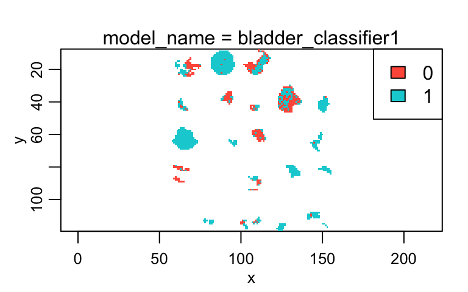

```r
image(micnn_supervised)
```

We can use `predict()` to predict the testing data using the trained model and visualize the results.

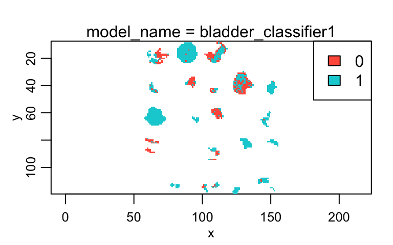

```r
micnn_supervised_predict <- predict(micnn_supervised, newx = mse_test, newy = mse_test$plabel)
image(micnn_supervised_predict)
```

Use `summary()` to summarize the performance of the trained model on testing data if the testing data has ground-truth labels.

```r
summary(micnn_supervised_predict)
```

```
## DNN classification:
##
##  Classification on 2 classes: 0 1
##  training = fully_supervised
##  epochs = 1
##
##       classifier_name         training  Accuracy Sensitivity Specificity
## 1 bladder_classifier1 fully_supervised 0.7412713   0.5398551   0.9380531
```

Use `topFeatures()` to rank mass features by weights of explanability. `lime` is a local model-agnostic explanation method, for more detals, please refer to https://github.com/marcotcr/lime. `instance_id` is the id of pixel to be expalined in the testing data. `n` is the number of m/z features the method returned. `topFeatures()` returns a list of m/z features and their coefficient in lime fitting. The higher the absolute value of the coefficient is, more important the m/z feature is for the model prediction. Positive value means supporting the model prediction while negative value means contradicts the model prediction.

```r
micnn_supervised_top <- topFeatures(micnn_supervised, train = train, test = test, method = 'lime', instance_id = 1, n = 10)
```

```
## [1] "from classification import explain\nfeature = explain.explain(bladder_classifier1, train_data = r.train, test_data = r.test, num_features = 10, instance_id = 1 )\n"
```

```r
micnn_supervised_top
```

```
## Top-ranked features:
##                                   mz         coef
## 1         mz944.546325683594 > 22.20  0.097552281
## 2  4.65 < mz1198.73132324219 <= 7.02 -0.036711991
## 3         mz945.550109863281 > 12.20  0.026468743
## 4         mz943.570190429688 > 11.36  0.024016514
## 5  3.58 < mz1199.73889160156 <= 5.20 -0.021096760
## 6  1.12 < mz1095.55310058594 <= 2.72  0.014721787
## 7         mz1111.68969726562 <= 0.89  0.014709643
## 8   0.52 < mz1850.9775390625 <= 0.87  0.010453564
## 9         mz1106.63708496094 <= 1.15  0.009850737
## 10        mz1081.66381835938 <= 1.19  0.009723586
```

Plot barplot of the top features.

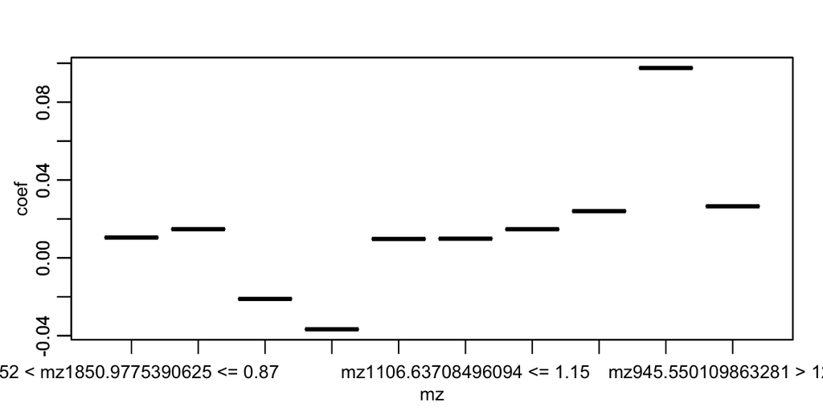

```r
plot(micnn_supervised_top)
```

# Multiple instance based training

```r
micnn <- multipleInstanceCNN(mse_train, mse_train$tlabel, model_name = 'bladder_classifier2', method = 'multiple_instance', num_epochs = 2)
```

Summarize the trained model.

```r
summary(micnn)
```

```
## DNN classification:
##
##  Classification on 2 classes: 0 1
##  training = multiple_instance
##  epochs = 2
##
##       classifier_name          training  Accuracy Sensitivity Specificity
## 1 bladder_classifier2 multiple_instance 0.7323187   0.3414634   0.9589816
```

Plot the predicted class.

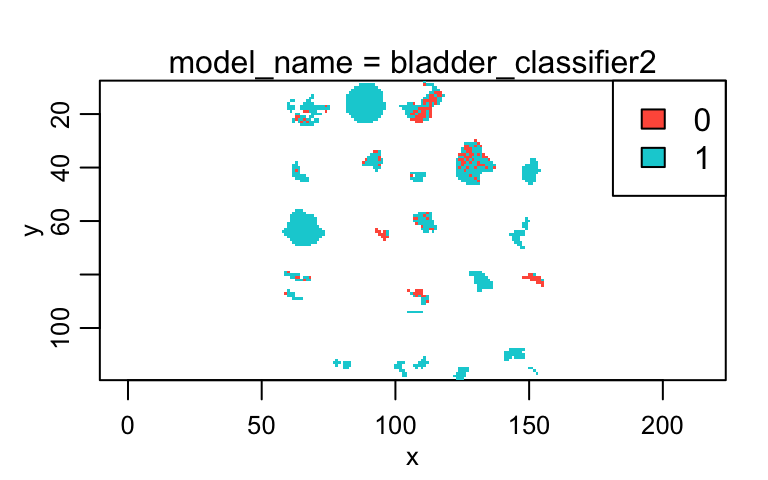

```r
image(micnn)
```

We can use `predict()` to predict the testing data using the trained model and visualize the results.

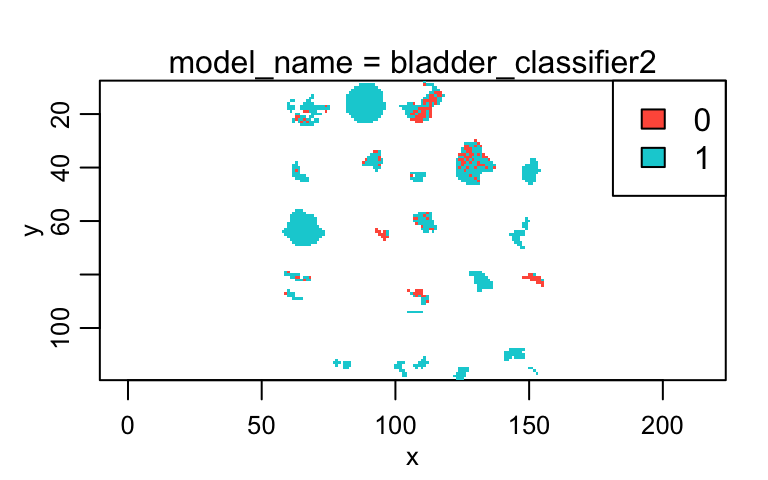

```r
micnn_predict <- predict(micnn, newx = mse_test, newy = mse_test$plabel)
image(micnn_predict)
```

Use `summary()` to summarize the performance of the trained model on testing data if the testing data has ground-truth labels.

```r
summary(micnn_predict)
```

```
## DNN classification:
##
##  Classification on 2 classes: 0 1
##  training = multiple_instance
##  epochs = 2
##
##       classifier_name          training  Accuracy Sensitivity Specificity
## 1 bladder_classifier2 multiple_instance 0.6535363   0.3025362   0.9964602
```

Use `topFeatures()` to rank mass features by weights of explanability.

```r
micnn_top <- topFeatures(micnn, train = train, test = test, trainmethod = 'lime', n = 10)
```

```
## [1] "from classification import explain\nfeature = explain.explain(bladder_classifier2, train_data = r.train, test_data = r.test, num_features = 10, instance_id = 1 )\n"
```

```r
micnn_top
```

```
## Top-ranked features:
##                                   mz        coef
## 1         mz944.546325683594 > 22.20  0.04328922
## 2         mz945.550109863281 > 12.20  0.03770033
## 3         mz943.570190429688 > 11.36  0.03148430
## 4         mz1105.62622070312 <= 1.35 -0.02528183
## 5  4.65 < mz1198.73132324219 <= 7.02  0.01822533
## 6         mz1111.68969726562 <= 0.89  0.01649652
## 7          mz1106.91918945312 > 0.06  0.01594172
## 8          mz1105.20373535156 > 0.09  0.01379910
## 9          mz985.575561523438 > 4.97 -0.01267322
## 10        mz1095.88818359375 <= 0.00  0.01205747
```

Plot bar plot of the top features.

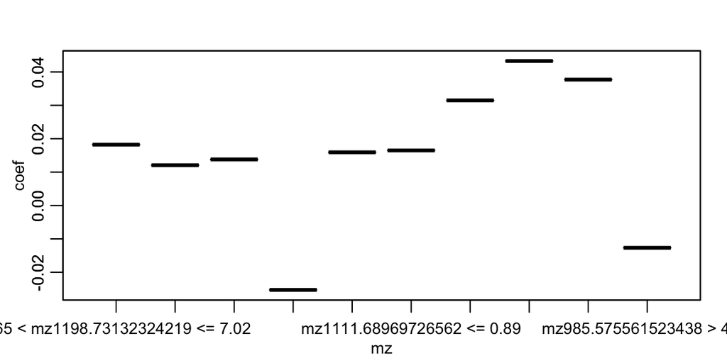

```r
plot(micnn_top)
```

# Access the results data

We can access the predictions using `resultData()’. The predictions contain the predicted classes and probabilities of each class.

```r
predicted_class <- resultData(micnn_predict)[[1]]$class
predicted_prob <- resultData(micnn_predict)[[1]]$probability
```

use it to subset the MSI data. Subsetting the pixels predicted as 0:

```r
mse_sub = mse_test[, predicted_class == 0]
mse_sub
```

```
## An object of class 'MSContinuousImagingExperiment'
##   <979 feature, 169 pixel> imaging dataset
##     imageData(1): intensity
##     featureData(0):
##     pixelData(5): 3DPositionX 3DPositionY sample plabel tlabel
##     metadata(8): spectrum representation ibd binary type ... files name
##     run(1): Preprocessed_TMA2
##     raster dimensions: 97 x 82
##     coord(2): x = 59..155, y = 9..90
##     mass range:  800.4446 to 2280.0256
##     centroided: TRUE
```

Subsetting the pixels predicted as 1:

```r
mse_sub = mse_test[,predicted_class == 1]
mse_sub
```

```
## An object of class 'MSContinuousImagingExperiment'
##   <979 feature, 948 pixel> imaging dataset
##     imageData(1): intensity
##     featureData(0):
##     pixelData(5): 3DPositionX 3DPositionY sample plabel tlabel
##     metadata(8): spectrum representation ibd binary type ... files name
##     run(1): Preprocessed_TMA2
##     raster dimensions: 98 x 112
##     coord(2): x = 58..155, y = 8..119
##     mass range:  800.4446 to 2280.0256
##     centroided: TRUE
```

We can visualize the predicted probabilities of the subset of pixels predicted as 1:

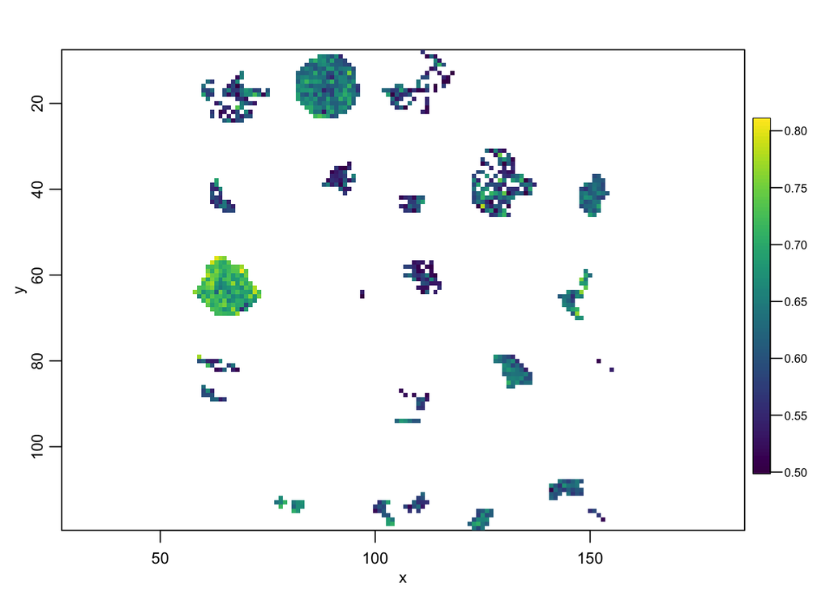

```r
image(mse_sub, predicted_prob[predicted_class==1]~x*y)
```

# Cross validation

When there’s no enough samples to split into training and testing data, unlike reporting the accuracy on the testing data, we can report the average accuracy of cross validation. First, we create the x-fold (5-fold for example) split of the data:

```r
set.seed(1)
folds <- split(unique(mse_train$sample), sample(20, 5))
fold_dataframe <- data.frame(unlist(folds), c(rep(1, 4), rep(2, 4), rep(3, 4), rep (4,4), rep(5,4)))
colnames(fold_dataframe) <- c("patient", "folds")
rownames(fold_dataframe) <- NULL

p_df <- data.frame(mse_train$sample)
colnames(p_df) <- 'patient'
joint_df <- merge(fold_dataframe, p_df, by = 'patient')

mse_train$folds <- joint_df$folds

table(mse_train$folds)
```

```
##
##   1   2   3   4   5
## 164 361 215 251 126
```

Then we fit CNN models for different folds and summarize the accuracy, sensitivity, and specificty:

```r
micnn_cv <- crossValidate(mse_train, mse_train$plabel,
                                .fun="multipleInstanceCNN",
                                .fold=mse_train$folds)
summary(micnn_cv)
```

```
## Cross validation:
##
##  Classification on 2 classes: 0 1
##  Summarized 5 folds: 1 2 3 4 5
##
##            model_name  Accuracy Sensitivity Specificity
## 1 bladder_classifier1 0.8696642   0.8369255   0.8681435
```